# Exploring the BRFSS data

## Setup

### Load packages

```r
library(ggplot2)
library(dplyr)
```

### Load data

```r
load("brfss2013.RData")
```

## Part 1: Data

The Behavioral Risk Factor Surveillance System or simply the BRFSS used stratified sampling for sample to be random but the participants were not put in control regarding the exercises to be performed, alcohol consumption, amount of sleep to be taken etc.Therefore, this is an observational study and is generalizable.

As per the CDC website, survey is done using landline or cellular telephone to monitor trends in public health but as the surveillance is only observational.Hence, no causal inference can be made.

## Part 2: Research questions

**Research question 1:**For the general population in the US, is there a correlation between the amount of sleep and chronic health condition such as diabetes? Specifically for those category of people who sleep for less than 6 hours.

Interest factor: As someone who often sacrifices sleep in order to meet the time requirements and have a family history of diabetes, I am interested to see how survey participants reported number of hours of sleep correlates to chronic health condition such as diabetes.

**Research question 2:**For the general population in the US, is there any correlation between a level of education obtained and income level? Further, are there any noticeable differences in this correlation between genders.

Interest factor: Are there any noticeable trends in income level for those that push hard to achieve high levels of formal education? As a strong proponent of self advancement through education, I am interested to see if there is any noticeable trends between those who complete more education and have high income level.

**Research question 3:**Is there any correlation between general health and smoking frequency? Further, are there any noticeable differences in this correlation between genders.

Interest factor: Are there any noticeable trends in general health for those who smoke? One would think smoking would damage general health.Therefore, I am interested to see the correlation between frequency of smoking and its effect on general health.

## Part 3: Exploratory data analysis

**Research question 1:**

```r
# Query the relevant variables
# sleptim1: How Much Time Do You Sleep
# diabete3: (Ever Told) You Have Diabetes

q1 <- brfss2013 %>%
  filter(!is.na(sleptim1),!is.na(diabete3),diabete3 != 'Yes, but female told only during pregnancy',
  diabete3 != 'No, pre-diabetes or borderline diabetes') %>%
  select(sleptim1,diabete3)
q11<- q1 %>%
  filter(sleptim1<6) %>%
  group_by(diabete3) %>%
  summarise(count=n())
#display

q11
```

```
## # A tibble: 2 x 2
##   diabete3 count
##   <fct>    <int>
## 1 Yes       9104
## 2 No       41477
```

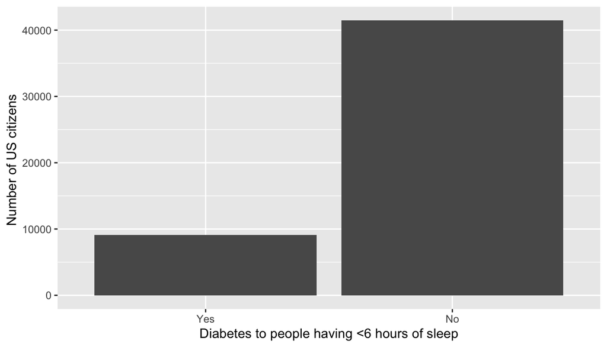

```r
# Plot relevant variables
# Use bar plot to observe relationship between amount of sleep and chronic health condition such as diabetes.

ggplot(data=q11,aes(x=diabete3,y=count))+geom_bar(stat = "identity")+
xlab("Diabetes to people having <6 hours of sleep")+ylab("Number of US citizens ")
```

**Research question 2:**

```r
# Query the relevant variables
# income2 : Income level
# educa: Education Level
# sex: Respondents Sex

q2 <- select(brfss2013, income2 , sex, educa) %>%
  filter(!is.na(income2), !is.na(sex), !is.na(educa))
q2 %>%
  group_by(income2) %>%
  summarise(count=n())
```

```
## # A tibble: 8 x 2
##   income2            count
##   <fct>              <int>
## 1 Less than $10,000  25381
## 2 Less than $15,000  26741
## 3 Less than $20,000  34793
## 4 Less than $25,000  41660
## 5 Less than $35,000  48795
## 6 Less than $50,000  61455
## 7 Less than $75,000  65186
## 8 $75,000 or more   115810
```

```r
q2 %>%
  group_by(educa) %>%
  summarise(count=n())
```

```
## # A tibble: 6 x 2
##   educa                                                         count
##   <fct>                                                         <int>
## 1 Never attended school or only kindergarten                      456
## 2 Grades 1 through 8 (Elementary)                               10256
## 3 Grades 9 though 11 (Some high school)                         22517
## 4 Grade 12 or GED (High school graduate)                       118660
## 5 College 1 year to 3 years (Some college or technical school) 116017
## 6 College 4 years or more (College graduate)                   151915
```

```r
q2 %>%
  group_by(sex) %>%
  summarise(count=n())
```

```
## # A tibble: 2 x 2
##   sex     count
##   <fct>   <int>
## 1 Male   177924
## 2 Female 241897
```

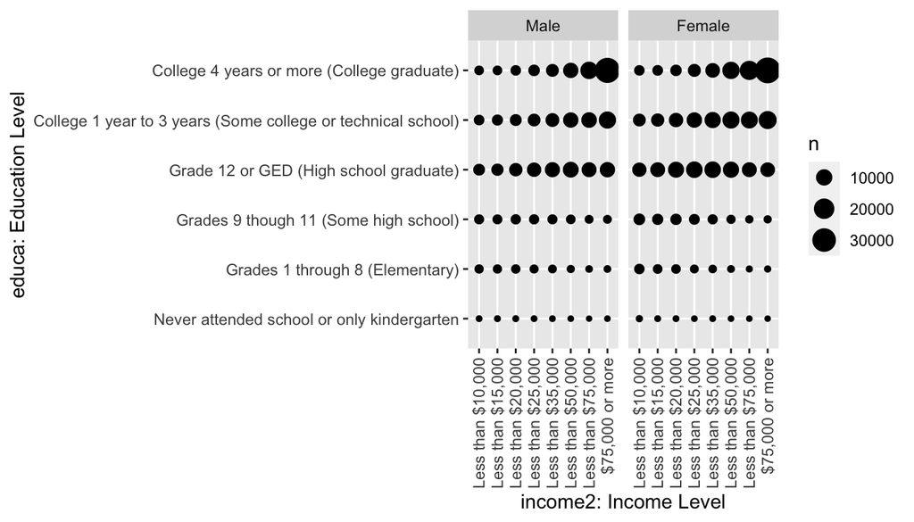

```r
# Plot relevant variables
# Use count plot to observe relationship between two categorical variables.
# Facet by gender to observe differences between the sexes.


ggplot(data = q2, aes(x = income2 , y = educa ))+
     geom_count () +
   theme(axis.text.x = element_text(angle = 90, vjust = 0.5, hjust=1))+
   facet_grid(. ~  sex) +
     xlab("income2: Income Level") +
     ylab ("educa: Education Level")
```

*Both genders are behaving similarly in the observation that income levels are greatest for those that have at least completed high school or the equivalent. Further, most respondents in this survey have completed at least high school, which may indicate there is some sort of systematic bias in the survey.*

**Research question 3:**

```r
# Query the relevant variables
# genhlth: General Health
# smokday2: Frequency Of Days Now Smoking
# sex: Respondents Sex

q3 <- select(brfss2013, genhlth ,smokday2, sex) %>%
  filter(!is.na(genhlth), !is.na(smokday2) , !is.na(sex))

# Present totals of variables being analyzed

q3 %>%
  group_by(genhlth) %>%
  summarise(count=n())
```

```
## # A tibble: 5 x 2
##   genhlth   count
##   <fct>     <int>
## 1 Excellent 28302
## 2 Very good 63534
## 3 Good      69618
## 4 Fair      35351
## 5 Poor      17071
```

```r
q3 %>%
  group_by(smokday2) %>%
  summarise(count=n())
```

```
## # A tibble: 3 x 2
##   smokday2    count
##   <fct>       <int>
## 1 Every day   54926
## 2 Some days   21393
## 3 Not at all 137557
```

```r
q3 %>%
  group_by(sex) %>%
  summarise(count=n())
```

```
## # A tibble: 2 x 2
##   sex     count
##   <fct>   <int>
## 1 Male   100347
## 2 Female 113529
```

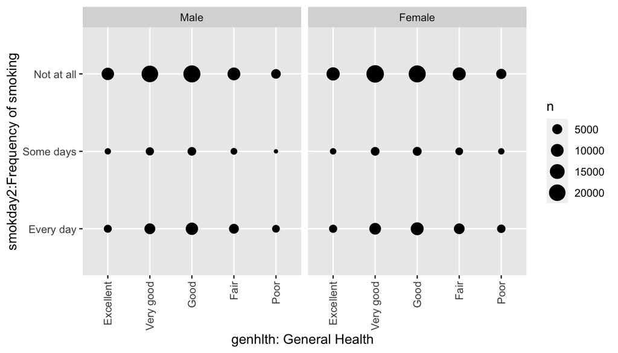

```r
# Plot relevant variables
# Use count plot to observe relationship between two categorical variables.
# Facet by gender to observe differences between the sexes.

ggplot(data = q3, aes(x = genhlth , y = smokday2))+
   geom_count () +
  theme(axis.text.x = element_text(angle = 90, vjust = 0.5, hjust=1))+
  facet_grid(. ~  sex) +
    xlab("genhlth: General Health ") +
    ylab ("smokday2:Frequency of smoking")
```